# Coding Assessment 2

Create a new `Quarto` file and copy the following statement into your new file. Then sign your name (by typing it) to the statement. Note that, in this and all future quizzes and assignments, full credit will not be given unless the statement and signature are present.

**Statement of Integrity**: “All work presented is my own, and I have followed all rules for collaboration. I have **not** used any AI for this assignment.”

**Important**: Remember to change your header so that the rendered `.html` file has all graphics and tables embedded within the file.

```
---
title: "Your Title"
author: "Your Name"
format:
  html:
    embed-resources: true
---
```

**Question 1** (10 points). A data set on United States election results was obtained from https://github.com/kjhealy/us_elections_2020_csv and has been put on Canvas for you to download and save to your `/data` folder. Use the `maps` package, as well as this data set and the code given below to construct a map that fills each U.S. State with the percent of voters who voted for the republican candidate, Trump (`percent_gop`). For this problem,

- you do not need to worry about including Alaska or Hawaii. They are important but this is a timed assessment!
- you should change the colour scale so that it is appropriate for the problem. Make sure that the scale you select is the appropriate type: sequential, diverging, or qualitative.
- you should explicitly specify the projection that you are using as an argument to the the appropriate function.

```r
library(maps)
library(tidyverse)
library(here)
election_df <- read_csv(here("data/2020_county_pres.csv")) |>
  group_by(state_name) |>
  summarise(total_gop = sum(votes_gop),
            total_dem = sum(votes_dem)) |>
  mutate(percent_gop = 100 * total_gop / (total_gop + total_dem)) |>
  mutate(state_name = str_to_lower(state_name))
```

**Question 2**. Using the STAT 113 survey data set, construct two plots that explore the trend in the popularity of Facebook among students through time, making sure to show some measure of variability in each graph. For both of the following plots, assume that:

- an `NA` value for all semesters prior to `F12` (including `F12`) mean that the question about facebook was not asked on the survey at all for these semesters.
- all `NA` value for all semesters after `F12` should be `0`’s.
1. (15 points). For the first plot, you should use the `Facebook` variable directly by making boxplots through time for each academic year. The `Facebook` variable corresponds to the number of friends a student reported to have on Facebook. Again, values from `F12` and before can be excluded while values after `F12` that are `NA` should be changed to 0’s before you construct your plot.

```r
library(here)
statsurvey_df <- read_csv(here("data/stat113_survey.csv"))
```

2. (20 points). Construct a graph that uses the proportion of students that have a Facebook for each academic year, along with a metric of variability for each proportion. For this question, assume that `0` `Facebook` friends means that the student does not have a Facebook account and more than `0` `Facebook` friends means that the student does have a Facebook account).
3. (5 points). The following side-by-side violin plot explores the distribution of `GPA` for students that do and do not have a `Tattoo` (after removing a couple of outliers for `GPA` that are above 4.0 and therefore are impossible to have). We see from the plot that the distributions in `GPA` for the two groups are quite similar, which is probably what we would expect. For the plot, complete the following:
- change the `x` and `y` axis labels
- add a title and subtitle to the plot
- change the y axis limits so that the lower limit is 0 and the upper limit is 4
- change the colour and fill colour of the violin plots

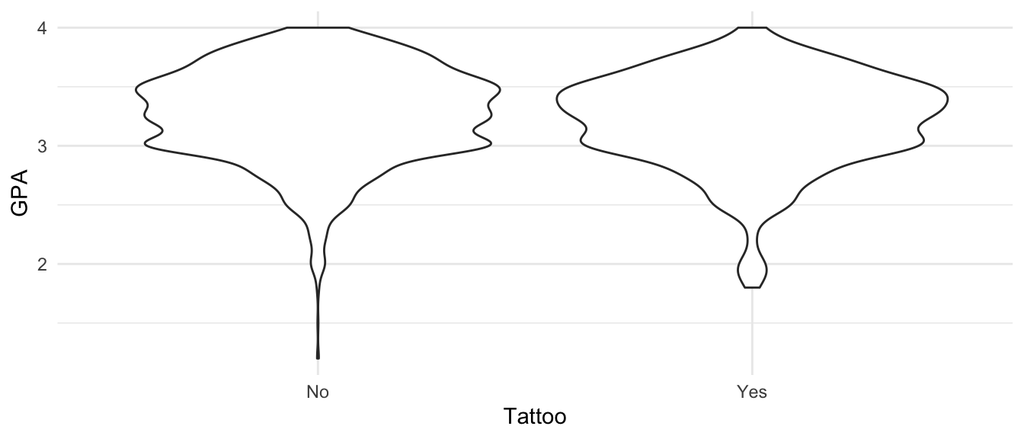

```r
statsurvey_partc <- statsurvey_df |> filter(GPA <= 4.0 & !is.na(Tattoo))
ggplot(data = statsurvey_partc, aes(x = Tattoo, y = GPA)) +
  geom_violin() +
  theme_minimal()
```